# Part I - Prosper Loan Data

## By: Joseph Tanner

## Introduction

The data set I will be exploring and then explaining is the Prosper Loan Data set. This data set contains 81 columns and 113937 rows. This data contains multiple different aspects of loan details. We will be using this loan data to break down inter-connections and make visualizations that tell a story for the data.

## Preliminary Wrangling

```python
# import all packages and set plots to be embedded inline
import numpy as np
import pandas as pd
import matplotlib.pyplot as plt
import seaborn as sb

%matplotlib inline
```

```python
# Load in the dataset as a ataframe using pandas
df_loan = pd.read_csv('pld.csv')
```

```python
# Gives me the number of rows and columns in the dataframe
df_loan.shape
```

```
(113937, 81)
```

```python
#Knowing there was a large amount of columns I adjusted the amount of columns shown.
pd.set_option('display.max_columns', 100)
# Then I want to open the first 5 rows of the dataset.
df_loan.head()
```

|  | ListingKey | ListingNumber | ListingCreationDate | CreditGrade | Term | LoanStatus | ClosedDate | BorrowerAPR | BorrowerRate | LenderYield | EstimatedEffectiveYield | EstimatedLoss | EstimatedReturn | ProsperRating (numeric) | ProsperRating (Alpha) | ProsperScore | ListingCategory (numeric) | BorrowerState | Occupation | EmploymentStatus | EmploymentStatusDuration | IsBorrowerHomeowner | CurrentlyInGroup | GroupKey | DateCreditPulled | CreditScoreRangeLower | CreditScoreRangeUpper | FirstRecordedCreditLine | CurrentCreditLines | … |
| --- | --- | --- | --- | --- | --- | --- | --- | --- | --- | --- | --- | --- | --- | --- | --- | --- | --- | --- | --- | --- | --- | --- | --- | --- | --- | --- | --- | --- | --- | --- |
| 0 | 1021339766868145413AB3B | 193129 | 2007-08-26 19:09:29.263000000 | C | 36 | Completed | 2009-08-14 00:00:00 | 0.16516 | 0.1580 | 0.1380 | NaN | NaN | NaN | NaN | NaN | NaN | 0 | CO | Other | Self-employed | 2.0 | True | True | NaN | 2007-08-26 18:41:46.780000000 | 640.0 | 659.0 | 2001-10-11 00:00:00 | 5.0 | … |
| 1 | 10273602499503308B223C1 | 1209647 | 2014-02-27 08:28:07.900000000 | NaN | 36 | Current | NaN | 0.12016 | 0.0920 | 0.0820 | 0.07960 | 0.0249 | 0.05470 | 6.0 | A | 7.0 | 2 | CO | Professional | Employed | 44.0 | False | False | NaN | 2014-02-27 08:28:14 | 680.0 | 699.0 | 1996-03-18 00:00:00 | 14.0 | … |
| 2 | 0EE9337825851032864889A | 81716 | 2007-01-05 15:00:47.090000000 | HR | 36 | Completed | 2009-12-17 00:00:00 | 0.28269 | 0.2750 | 0.2400 | NaN | NaN | NaN | NaN | NaN | NaN | 0 | GA | Other | Not available | NaN | False | True | 783C3371218786870A73D20 | 2007-01-02 14:09:10.060000000 | 480.0 | 499.0 | 2002-07-27 00:00:00 | NaN | … |
| 3 | 0EF5356002482715299901A | 658116 | 2012-10-22 11:02:35.010000000 | NaN | 36 | Current | NaN | 0.12528 | 0.0974 | 0.0874 | 0.08490 | 0.0249 | 0.06000 | 6.0 | A | 9.0 | 16 | GA | Skilled Labor | Employed | 113.0 | True | False | NaN | 2012-10-22 11:02:32 | 800.0 | 819.0 | 1983-02-28 00:00:00 | 5.0 | … |
| 4 | 0F023589499656230C5E3E2 | 909464 | 2013-09-14 18:38:39.097000000 | NaN | 36 | Current | NaN | 0.24614 | 0.2085 | 0.1985 | 0.18316 | 0.0925 | 0.09066 | 3.0 | D | 4.0 | 2 | MN | Executive | Employed | 44.0 | True | False | NaN | 2013-09-14 18:38:44 | 680.0 | 699.0 | 2004-02-20 00:00:00 | 19.0 | … |

```python
# I want to see all the diferent data types and the amount of data that is missing.
df_loan.info()
```

```
<class 'pandas.core.frame.DataFrame'>
RangeIndex: 113937 entries, 0 to 113936
Data columns (total 81 columns):
ListingKey                             113937 non-null object
ListingNumber                          113937 non-null int64
ListingCreationDate                    113937 non-null object
CreditGrade                            28953 non-null object
Term                                   113937 non-null int64
LoanStatus                             113937 non-null object
ClosedDate                             55089 non-null object
BorrowerAPR                            113912 non-null float64
BorrowerRate                           113937 non-null float64
LenderYield                            113937 non-null float64
EstimatedEffectiveYield                84853 non-null float64
EstimatedLoss                          84853 non-null float64
EstimatedReturn                        84853 non-null float64
ProsperRating (numeric)                84853 non-null float64
ProsperRating (Alpha)                  84853 non-null object
ProsperScore                           84853 non-null float64
ListingCategory (numeric)              113937 non-null int64
BorrowerState                          108422 non-null object
Occupation                             110349 non-null object
EmploymentStatus                       111682 non-null object
EmploymentStatusDuration               106312 non-null float64
IsBorrowerHomeowner                    113937 non-null bool
CurrentlyInGroup                       113937 non-null bool
GroupKey                               13341 non-null object
DateCreditPulled                       113937 non-null object
CreditScoreRangeLower                  113346 non-null float64
CreditScoreRangeUpper                  113346 non-null float64
FirstRecordedCreditLine                113240 non-null object
CurrentCreditLines                     106333 non-null float64
OpenCreditLines                        106333 non-null float64
TotalCreditLinespast7years             113240 non-null float64
OpenRevolvingAccounts                  113937 non-null int64
OpenRevolvingMonthlyPayment            113937 non-null float64
InquiriesLast6Months                   113240 non-null float64
TotalInquiries                         112778 non-null float64
CurrentDelinquencies                   113240 non-null float64
AmountDelinquent                       106315 non-null float64
```

[output cut: 31 more lines]

```
LP_CustomerPayments                    113937 non-null float64
LP_CustomerPrincipalPayments           113937 non-null float64
LP_InterestandFees                     113937 non-null float64
LP_ServiceFees                         113937 non-null float64
LP_CollectionFees                      113937 non-null float64
LP_GrossPrincipalLoss                  113937 non-null float64
LP_NetPrincipalLoss                    113937 non-null float64
LP_NonPrincipalRecoverypayments        113937 non-null float64
PercentFunded                          113937 non-null float64
Recommendations                        113937 non-null int64
InvestmentFromFriendsCount             113937 non-null int64
InvestmentFromFriendsAmount            113937 non-null float64
Investors                              113937 non-null int64
dtypes: bool(3), float64(50), int64(11), object(17)
memory usage: 68.1+ MB
```

```python
# This shows me how many missing rows i have in each column.
df_loan.isnull().sum(axis = 0)
```

```
ListingKey                                  0
ListingNumber                               0
ListingCreationDate                         0
CreditGrade                             84984
Term                                        0
LoanStatus                                  0
ClosedDate                              58848
BorrowerAPR                                25
BorrowerRate                                0
LenderYield                                 0
EstimatedEffectiveYield                 29084
EstimatedLoss                           29084
EstimatedReturn                         29084
ProsperRating (numeric)                 29084
ProsperRating (Alpha)                   29084
ProsperScore                            29084
ListingCategory (numeric)                   0
BorrowerState                            5515
Occupation                               3588
EmploymentStatus                         2255
EmploymentStatusDuration                 7625
IsBorrowerHomeowner                         0
CurrentlyInGroup                            0
GroupKey                               100596
DateCreditPulled                            0
CreditScoreRangeLower                     591
CreditScoreRangeUpper                     591
FirstRecordedCreditLine                   697
CurrentCreditLines                       7604
OpenCreditLines                          7604
                                        ...
TotalProsperLoans                       91852
TotalProsperPaymentsBilled              91852
OnTimeProsperPayments                   91852
ProsperPaymentsLessThanOneMonthLate     91852
ProsperPaymentsOneMonthPlusLate         91852
ProsperPrincipalBorrowed                91852
ProsperPrincipalOutstanding             91852
ScorexChangeAtTimeOfListing             95009
LoanCurrentDaysDelinquent                   0
LoanFirstDefaultedCycleNumber           96985
LoanMonthsSinceOrigination                  0
LoanNumber                                  0
LoanOriginalAmount                          0
LoanOriginationDate                         0
LoanOriginationQuarter                      0
MemberKey                                   0
MonthlyLoanPayment                          0
LP_CustomerPayments                         0
LP_CustomerPrincipalPayments                0
LP_InterestandFees                          0
LP_ServiceFees                              0
LP_CollectionFees                           0
LP_GrossPrincipalLoss                       0
LP_NetPrincipalLoss                         0
LP_NonPrincipalRecoverypayments             0
PercentFunded                               0
Recommendations                             0
InvestmentFromFriendsCount                  0
InvestmentFromFriendsAmount                 0
Investors                                   0
Length: 81, dtype: int64
```

```python
#Credit score is currently two columns. To fix this we ad the two columns together and find the average.
#Then make this a new column
CreditScore = (((df_loan.CreditScoreRangeLower) +(df_loan.CreditScoreRangeUpper))/2)
print(CreditScore.head())
```

```
0    649.5
1    689.5
2    489.5
3    809.5
4    689.5
dtype: float64
```

```python
#Ad this new column to our dataframe.
df_loan['CreditScore'] = CreditScore
```

```python
#We are going to chunck the data we want to use into a new dataframe. Then use the two dataframes to make graphing easier.
df1 = ['LoanOriginalAmount', 'CreditScore', 'BorrowerAPR', 'StatedMonthlyIncome', 'Term', 'ProsperRating (Alpha)', 'EmploymentStatus']
df = df_loan[df1]
```

```python
#Testing my new dataframe
df.head()
```

|  | LoanOriginalAmount | CreditScore | BorrowerAPR | StatedMonthlyIncome | Term | ProsperRating (Alpha) | EmploymentStatus |
| --- | --- | --- | --- | --- | --- | --- | --- |
| 0 | 9425 | 649.5 | 0.16516 | 3083.333333 | 36 | NaN | Self-employed |
| 1 | 10000 | 689.5 | 0.12016 | 6125.000000 | 36 | A | Employed |
| 2 | 3001 | 489.5 | 0.28269 | 2083.333333 | 36 | NaN | Not available |
| 3 | 10000 | 809.5 | 0.12528 | 2875.000000 | 36 | A | Employed |
| 4 | 15000 | 689.5 | 0.24614 | 9583.333333 | 36 | D | Employed |

```python
#This describes the data in the dataframe to give more information before graphing.
df.describe()
```

|  | LoanOriginalAmount | CreditScore | BorrowerAPR | StatedMonthlyIncome | Term |
| --- | --- | --- | --- | --- | --- |
| count | 113937.00000 | 113346.000000 | 113912.000000 | 1.139370e+05 | 113937.000000 |
| mean | 8337.01385 | 695.067731 | 0.218828 | 5.608026e+03 | 40.830248 |
| std | 6245.80058 | 66.458275 | 0.080364 | 7.478497e+03 | 10.436212 |
| min | 1000.00000 | 9.500000 | 0.006530 | 0.000000e+00 | 12.000000 |
| 25% | 4000.00000 | 669.500000 | 0.156290 | 3.200333e+03 | 36.000000 |
| 50% | 6500.00000 | 689.500000 | 0.209760 | 4.666667e+03 | 36.000000 |
| 75% | 12000.00000 | 729.500000 | 0.283810 | 6.825000e+03 | 36.000000 |
| max | 35000.00000 | 889.500000 | 0.512290 | 1.750003e+06 | 60.000000 |

```python
#Removing rows with missing APR and credit score. This helps make our data cleaner.
df=df[~df.BorrowerAPR.isna()]
df=df[~df.CreditScore.isna()]
```

### What is the structure of your dataset?

There are 81 columns and 113937 rows

### What is/are the main feature(s) of interest in your dataset?

The main feature of our data set that i would like to explore is how the ifferent aspects of a loan affect APR.

### What features in the dataset do you think will help support your investigation into your feature(s) of interest?

The different aspects of the loan that i think will help with our exploration the most would be Credit Score, Loan original amount, an term.

## Univariate Exploration

```python
def plotFunction(plt, title, xlabel, ylabel):
    #Here we are going to set up a function to help eliminate repeated functions.
    plt.title(title)
    plt.xlabel(xlabel)
    plt. ylabel
```

First, I'm going to plot the features I am the most interested in exploring.

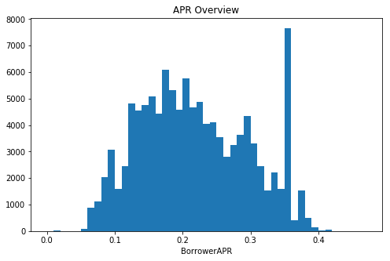

```python
#We are going to set up our bins to fit our data.
bins = np.arange(0, df.BorrowerAPR.max()+0.05, 0.01)
#set the size of our graph
plt.figure(figsize=[8, 5])
#plot BorrowerAPR as a histograph.
plt.hist(data = df, x = 'BorrowerAPR', bins = bins)
#Now we are going to label our graph accordinly
plotFunction(plt,'APR Overview', 'BorrowerAPR','Frequency')
```

The distribution of the Borrower APR looks to be multimodal with peaks centered at diferent points.

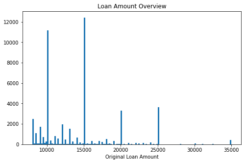

```python
# Set up our bins to fit our data
bins = np.arange(8000, df.LoanOriginalAmount.max()+200, 200)
#Set the size of our graph
plt.figure(figsize=[8, 5])
#Plot LoanOriginalAmount as a histograph
plt.hist(data = df, x = 'LoanOriginalAmount', bins = bins)
#Label our Graph Accordingly
plotFunction(plt,'Loan Amount Overview', 'Original Loan Amount','Frequency')
```

Next, I want to look at the Original Loan Amounts. There seems to be a spikes at specific intervals such as 10k, 15k, 20k, 25k, 30k, and 35k. It looks like these set amounts are more popular than inbetween numbers.

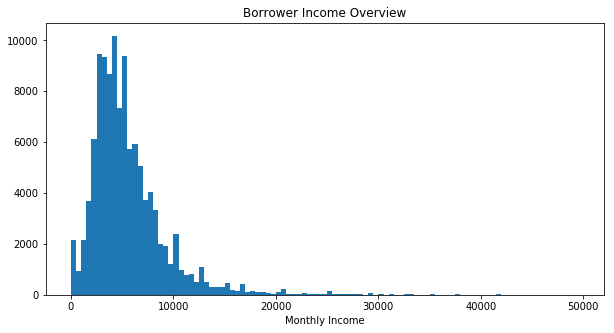

```python
#Set our bins to view our data efficiently
bins_smi = np.arange(0,50000,500)
#Set our plot size
plt.figure(figsize=[10,5])
#Plot StatedMonthlyIncome as a Histograph
plt.hist(data=df, x ='StatedMonthlyIncome',bins=bins_smi)
#Label our graph accordingly so that it is readable.
plotFunction(plt,'Borrower Income Overview', 'Monthly Income','Frequency')
```

Now, lets look at the mopnthly stated income. It looks like our data is skewed to the right. This shows the vast majority of people are bringing in less than 30k a month.

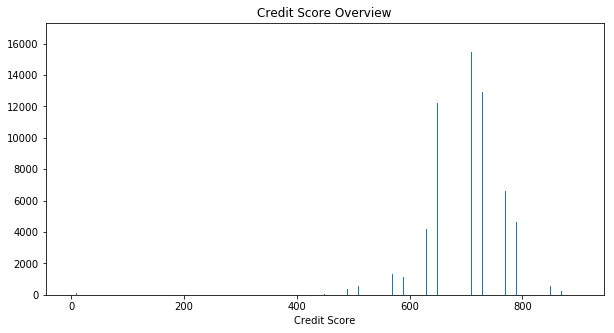

```python
#Set our bins to fit our data effectively
bins = np.arange(0,900)
#set the plot size for the data
plt.figure(figsize=[10, 5])
#Plot CreditScore as a histograph
plt.hist(data = df, x = 'CreditScore', bins = bins)
#Label the graph accordingly so it can be easily recognized
plotFunction(plt,'Credit Score Overview', 'Credit Score','Frequency')
```

Credit Score is the varriable i am the most interested in. There is a lot of media in the world around credit scores. That makes this variable the most interesting. First we will start by seeing a overview of the CreditScore of the borrowers.

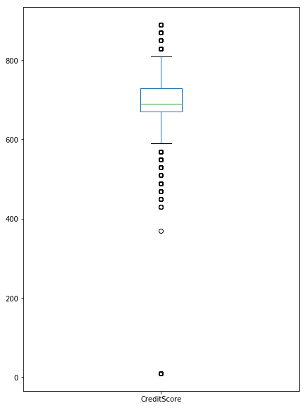

```python
#I wanted to further explore Credit Score so plotted it as a box plot
df.CreditScore.plot.box(figsize=(7,10))
```

Now that we have the overview of the credit score, lets plot it as a box plot to get a better idea of the the ranges in the data.

```
Text(0,0.5,'Frequency')
```

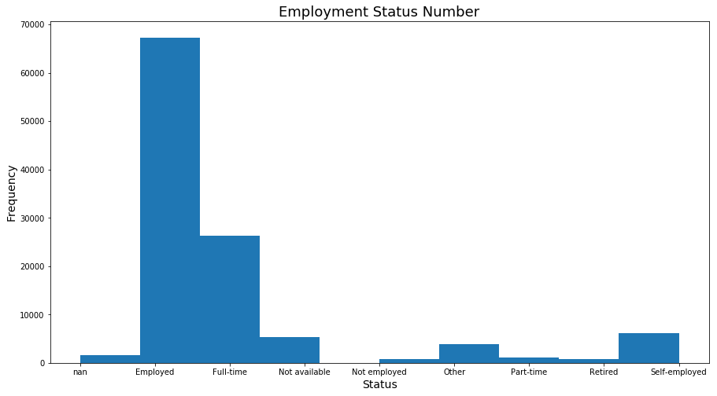

```python
#Set our graph size to fit the data
plt.figure(figsize=[15, 8])
#Set EmployeeStatus as the data for our histograph
plt.hist(data = df, x = 'EmploymentStatus')
#Label our graph for ease of reading
plt.title('Employment Status Number', fontsize=18)
plt.xlabel('Status', fontsize=14)
plt.ylabel('Frequency', fontsize=14)
```

Now that we have a lot of the numbers figured out, I want to look at more of the data that is categorical like employment status. It looks like the majority of loan borrowers are employed.

```
Text(0,0.5,'Frequency')
```

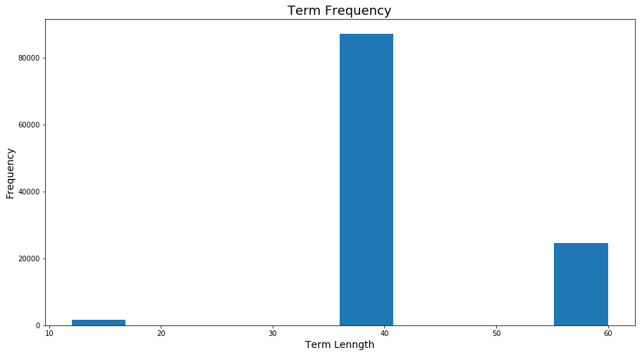

```python
#Set our graph size to fit the data
plt.figure(figsize=[15, 8])
#Set Term as the data for our histograph
plt.hist(data = df, x = 'Term')
#Label our graph for ease of reading
plt.title('Term Frequency', fontsize=18)
plt.xlabel('Term Lenngth', fontsize=14)
plt.ylabel('Frequency', fontsize=14)
```

Finally we will get an overview of Term lengths. Looks like the majority of loans are 36 months.

### Discuss the distribution(s) of your variable(s) of interest. Were there any unusual points? Did you need to perform any transformations?

The two variable we were interest in were APR an Credit score. Credit score looked normal except with some low outliers, and APR looked to be multimodal. The transformations i made was taking a two variable creit score and making it one columns.

### Of the features you investigated, were there any unusual distributions? Did you perform any operations on the data to tidy, adjust, or change the form of the data? If so, why did you do this?

For unusual data I found that the stated monthly income was interesting. There were a small amount of borrowers that stated they made over 30,000 a month.

## Bivariate Exploration

```
Text(0,0.5,'APR')
```

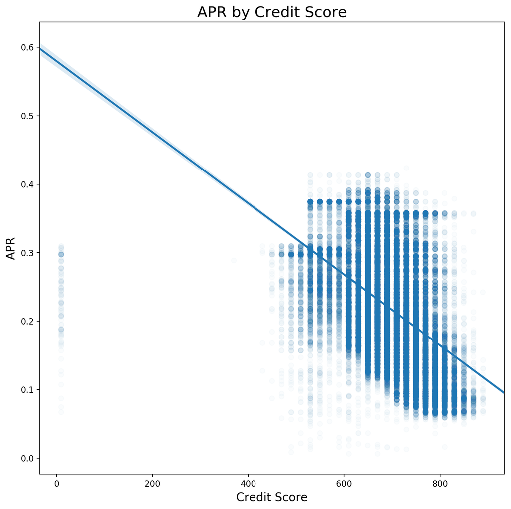

```python
#Set the graph size to fit our data
plt.figure(figsize=(10, 10), dpi=200)
#Use seaborn to create a bivariate plot with CreditScore and APR using jitter
sb.regplot(data=df, x ='CreditScore',y='BorrowerAPR',x_jitter=0.3,scatter_kws={'alpha' :1/50})
#Label our graph for ease of reading.
plt.title('APR by Credit Score', fontsize=18)
plt.xlabel('Credit Score', fontsize=14)
plt.ylabel('APR',fontsize=14)
```

```
Text(0,0.5,'Loan Amount')
```

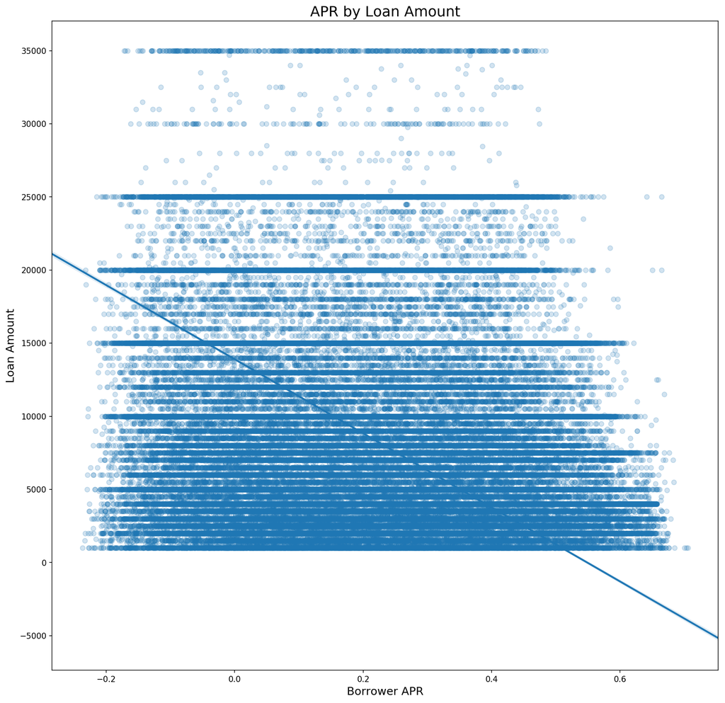

```python
#Set the size for our graph
plt.figure(figsize=(15, 15), dpi=150)
#Use Seaborn to call a bivariate plot with Borrower APR and LoanOriginalAMount using jitter
sb.regplot(data=df, x ='BorrowerAPR',y='LoanOriginalAmount',x_jitter=0.3,scatter_kws={'alpha' :1/5})
#Label our graph accordingly
plt.title('APR by Loan Amount', fontsize=18)
plt.xlabel('Borrower APR', fontsize=14)
plt.ylabel('Loan Amount',fontsize=14)
```

Next lets see the affects of loan amount on apr. As we can see in this graph there is a negative correlation. The higher the original loan amount the lower the APR.

```
Text(0,0.5,'Stated Monthly Income')
```

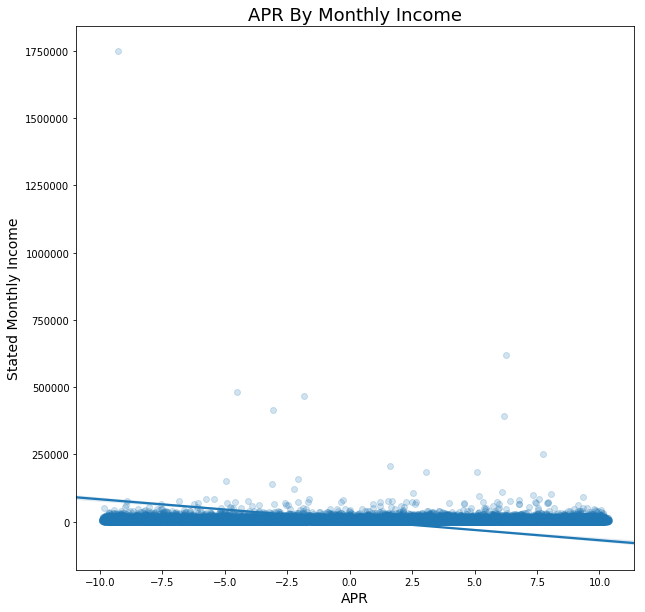

```python
#Lets set our graph size
plt.figure(figsize=(10, 10))
#Now lets graph using jitter to make the data easier to view
sb.regplot(data=df,x = 'BorrowerAPR',y = 'StatedMonthlyIncome',x_jitter=10,scatter_kws={'alpha' :1/5})
#Now we can label our graph
plt.title('APR By Monthly Income', fontsize=18)
plt.xlabel('APR',fontsize=14)
plt.ylabel('Stated Monthly Income',fontsize=14)
```

Next i wanted to look at monthly incomer and see how that changed apr. Based on the graph it doesnt look like there is any correlation between the two.

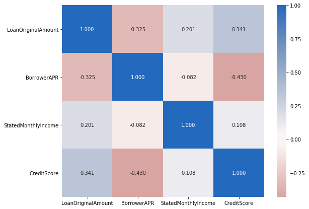

```python
#Lets break up the data we need to make a heat map graph
NV = ['LoanOriginalAmount','BorrowerAPR','StatedMonthlyIncome','CreditScore']
CV = ['term', 'ProsperRating (alpha)', 'EmploymentStatus']
#Now lets set the size of the graph
plt.figure(figsize=[9,7])
#Finally we can use the callbacks we made to call the data we need into the graph
sb.heatmap(df[NV].corr(),annot = True, fmt='.3f', cmap = 'vlag_r', center = 0)
```

Now that we have an overview of our data points lets see the correlation between the variables we are most interested in. As you can see in the heat map Credit Score and Borrower APR have the highest correlation of any group at -.43. This shows that the higher the credit score the lower the apr.

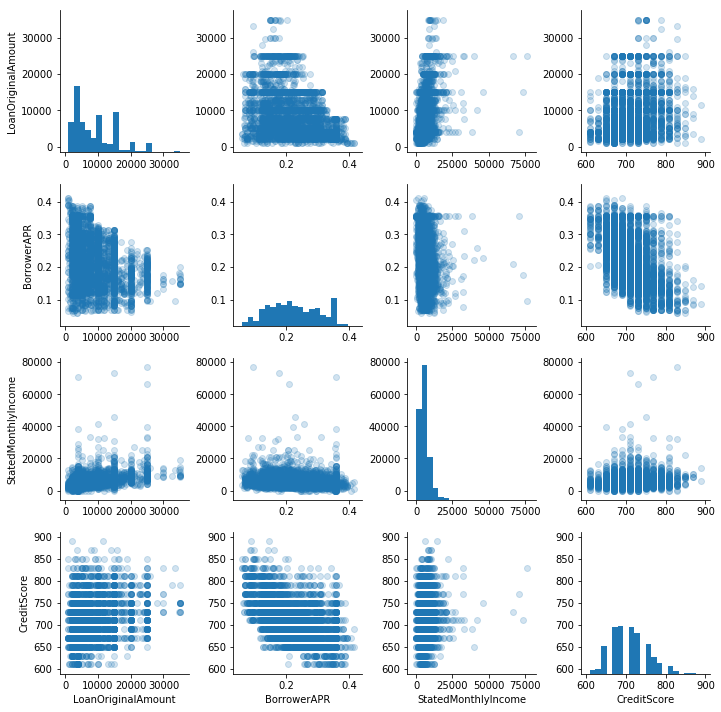

```python
#Lets create a sample of our own data to make get an overview of all relationships
sample_data = df.sample(5000)
##Now we can start building our graph by dropping some data we dont need.
g = sb.PairGrid(data=sample_data.dropna(), vars = NV)
#Set our bins
g = g.map_diag(plt.hist, bins = 20)
#Plot the data
g.map_offdiag(plt.scatter, alpha = 0.2)
```

Lets look at these variables in another format. In this spread of information we can multiple relationships between data. The first one that standsa out is the same one from the last graph credit score and apr. You can see the negative correlation in the data. Next is APR and loan amount. You can see the negative correlation between these as well. The third relationship would be loan original amount and credit score. This is a positive corelation and you can see the data trend upwar.

### Talk about some of the relationships you observed in this part of the investigation. How did the feature(s) of interest vary with other features in the dataset?

I think we were able to see the highest negative correlation was APR an CreditScore. This helps support our hypothesis that the higher your credit score the lower your APR.

### Did you observe any interesting relationships between the other features (not the main feature(s) of interest)?

There was a positive correlation between stated monthly income and credit score. I think this makes sense those that make more are more likely to pay their bills on time.

## Multivariate Exploration

```python
#Lets set the order we wont the prosper ratings to be in
rating_order = ['HR', 'E', 'D', 'C', 'B', 'A', 'AA']
ordered_var = pd.api.types.CategoricalDtype(categories = rating_order, ordered = True)
#Make the changes needed to the dataframe
df['ProsperRating (Alpha)'] = df['ProsperRating (Alpha)'].astype(ordered_var)
#Test our results
df.info()
```

```
<class 'pandas.core.frame.DataFrame'>
Int64Index: 113346 entries, 0 to 113936
Data columns (total 7 columns):
LoanOriginalAmount       113346 non-null int64
CreditScore              113346 non-null float64
BorrowerAPR              113346 non-null float64
StatedMonthlyIncome      113346 non-null float64
Term                     113346 non-null int64
ProsperRating (Alpha)    84853 non-null category
EmploymentStatus         111680 non-null object
dtypes: category(1), float64(3), int64(2), object(1)
memory usage: 6.2+ MB
```

```
Text(0,0.5,'APR')
```

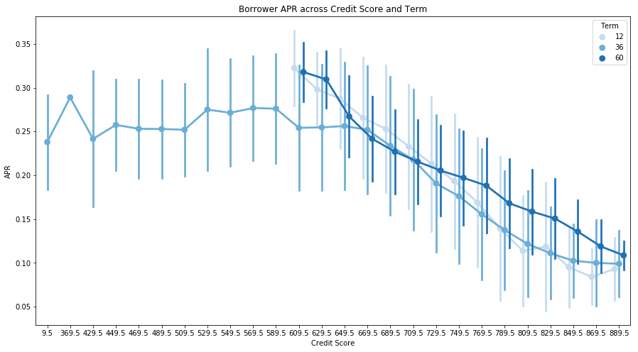

```python
#Set our graph size for our first multivariate graph.
fig = plt.figure(figsize=[15,8])
#Set up our graph data with credit score as the x, borrower apr as the y and the hue or third variable as the term.
ax = sb.pointplot(data=df, x = 'CreditScore', y = 'BorrowerAPR', hue = 'Term', palette = 'Blues', linestyle = '',dodge = 0.4, ci = 'sd')
#Label our graph
plt.title('Borrower APR across Credit Score and Term')
#Set the tick marks for ease of reading
ax.set_yticklabels([],minor = True)
plt.xlabel('Credit Score')
plt.ylabel('APR')
```

```
[]
```

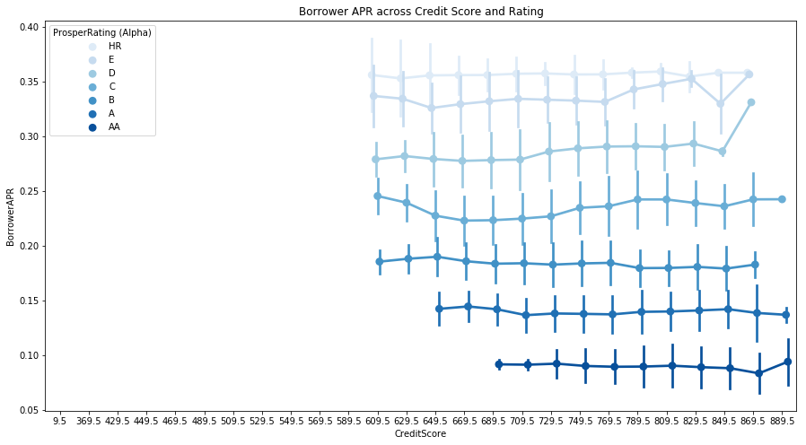

```python
#Set our graph size
fig = plt.figure(figsize=[15,8])
#Arrange the graph to the variables we need x=credit score, y= borrowerapr, hue is prosper rating
ax = sb.pointplot(data=df, x = 'CreditScore', y = 'BorrowerAPR', hue = 'ProsperRating (Alpha)', palette = 'Blues', linestyle = '',dodge = 0.4, ci = 'sd')
#Label our graph and set the tick marks
plt.title('Borrower APR across Credit Score and Rating')
ax.set_yticklabels([],minor = True)
```

Next i want to change from term to loan grade. As we can see Loan grade and credit score have the largest impact on apr so far. The better the grade and the higher the credit score the lower the apr will be.

```
[]
```

[figure not shown]

```python
#set the size of our graph
fig = plt.figure(figsize=[15,8])
#arrange varriables as needed x = prosper rating, y = credit score, hue = term.
ax = sb.pointplot(data=df, x = 'ProsperRating (Alpha)', y = 'CreditScore', hue = 'Term', palette = 'Blues', linestyle = '',dodge = 0.4, ci = 'sd')
plt.title('Borrower APR across Credit Score and Rating')
ax.set_yticklabels([],minor = True)
```

Finally before we wrap up, I want to take a look at term, loan rating and credit score. As we can see loan grade is effected heavily by the credit score and term lengthy looks to be effected as well.

### Talk about some of the relationships you observed in this part of the investigation. Were there features that strengthened each other in terms of looking at your feature(s) of interest?

In the multivariate exploration we were able to see what variables effected the apr the most. In our Exploration we were able to see Term length, Credit Score and Loan Grade had the highest impact on apr.

### Were there any interesting or surprising interactions between features?

Some suprising and interesting findings was that monthly income had no effect on apr.

## Conclusions

Citations

https://mode.com/python-tutorial/counting-and-plotting-in-python/

https://matplotlib.org/3.1.1/api/_as_gen/matplotlib.pyplot.title.html

https://stackoverflow.com/questions/59559682/how-to-change-pandas-dataframe-plot-fontsize-of-xlabel

https://pandas.pydata.org/docs/user_guide/visualization.html#box-plots

https://stackoverflow.com/questions/31842892/how-to-add-labels-to-a-boxplot-figure-pylab

https://www.statology.org/bivariate-analysis-in-python/

https://stackoverflow.com/questions/39712767/how-to-set-size-for-scatter-plot